# Regularized Precision Matrix Estimation via ADMM

Matt Galloway

Abstract

`ADMMsigma` is an R package that estimates a penalized precision matrix via the alternating direction method of multipliers (ADMM) algorithm. This report will provide a brief overview of the algorithm and detail how it can be utilized to estimate precision matrices of joint normal distributions. In addition, examples and simulation results will be provided for `ADMMsigma`.

# Introduction

Suppose we want to minimize $f(x) + g(z)$ subject to the constraint that $Ax + Bz = c$. For now, we will take $x \in \mathbb{R}^{n}, z \in \mathbb{R}^{m}, A \in \mathbb{R}^{p \times m}, B \in \mathbb{R}^{p \times m}, c \in \mathbb{R}^{p}$ – though we will later consider cases where $x$ and $z$ are matrices. The *augmented lagrangian* is constructed as follows:

$$L_{\rho}(x, z, y) = f(x) + g(z) + y^{T}(Ax + Bz - c) + \frac{\rho}{2}\left\| Ax + Bz - c \right\|_{2}^{2}$$

where $y \in \mathbb{R}^{p}$ is the lagrange multiplier. The optimal value is

$$p^{*} = inf\left\{ f(x) + g(z) | Ax + Bz = c \right\}$$

Clearly, the minimization problem under the augmented lagrangian (RE-WORK) is equivalent to that of the usual lagrangian since any feasible point $(x, z)$ satisfies the constraint $\rho\left\| Ax + Bz - c \right\|_{2}^{2}/2 = 0$.

The ADMM algorithm consists of the following repeated iterations:

$$\begin{align}
x^{k + 1} &:= \arg\min_{x}L_{\rho}(x, z^{k}, y^{k}) \\
z^{k + 1} &:= \arg\min_{z}L_{\rho}(z^{k + 1}, z, y^{k}) \\
y^{k + 1} &:= y^{k} + \rho(Ax^{k + 1} + Bz^{k + 1} - c)
\end{align}$$

A more complete introduction to the algorithm – specifically how it arose out of *dual ascent* and *method of multipliers* – can be found in Boyd, et al. (2011).

# Regularized Precision Matrix Estimation

We now consider the case where $X_{1}, ..., X_{n}$ are iid $N_{p}(\mu, \Sigma)$ and we are tasked with estimating the precision matrix, denoted $\Omega \equiv \Sigma^{-1}$. The maximum likelihood estimator for $\Omega$ is

$$\hat{\Omega} = \arg\min_{\Omega \in S_{+}^{p}}\left\{ Tr\left(S\Omega\right) - \log \det\left(\Omega \right) \right\}$$

where $S = \sum_{i = 1}^{n}(X_{i} - \bar{X})(X_{i} - \bar{X})^{T}/n$. It is straight forward to show that when the solution exists, $\hat{\Omega} = S^{-1}$.

We can further construct a penalized likelihood estimator by adding a penalty term, $P_{\lambda}\left( \Omega \right)$, to the likelihood:

$$\hat{\Omega}_{\lambda} = \arg\min_{\Omega \in S_{+}^{p}}\left\{ Tr\left(S\Omega\right) - \log \det\left(\Omega \right) + P_{\lambda}\left( \Omega \right) \right\}$$

Throughout the rest of this document we will take $P_{\lambda}\left( \Omega \right)$ to be $P_{\lambda}\left( \Omega \right) = \lambda\left[\frac{1 - \alpha}{2}\left\| \Omega \right|_{F}^{2} + \alpha\left\| \Omega \right\|_{1} \right]$ so that the full penalized likelihood is as follows:

$$\hat{\Omega}_{\lambda} = \arg\min_{\Omega \in S_{+}^{p}}\left\{ Tr\left(S\Omega\right) - \log \det\left(\Omega \right) + \lambda\left[\frac{1 - \alpha}{2}\left\| \Omega \right|_{F}^{2} + \alpha\left\| \Omega \right\|_{1} \right] \right\}$$

where $0 \leq \alpha \leq 1$, $\lambda > 0$, $0 < \eta < 2$, $\left\|\cdot \right\|_{F}^{2}$ is the Frobenius norm and we define $\left\|A \right\|_{1} = \sum_{i, j} \left| A_{ij} \right|$. This penalty is closely related to the elastic-net penalty explored by Hui Zou and Trevor Hastie . Clearly, when $\alpha = 0$ this reduces to a ridge-type penalty and when $\alpha = 1$ this reduces to a lasso-type penalty.

By letting $f$ be equal to the non-penalized likelihood and $g$ equal to $P_{\lambda}\left( \Omega \right)$, our goal is to minimize the full augmented lagrangian where the constraint is that $\Omega - Z$ is equal to zero:

$$L_{\rho}(\Omega, Z, \Lambda) = f\left(\Omega\right) + g\left(Z\right) + Tr\left[\Lambda\left(\Omega - Z\right)\right] + \frac{\rho}{2}\left\|\Omega - Z\right\|_{F}^{2}$$

The ADMM algorithm for regularized precision matrix estimation is

$$\begin{align}
\Omega^{k + 1} &= \arg\min_{S\Omega}\left\{ Tr\left(\Omega\right) - \log\det\left(\Omega\right) + Tr\left[\Lambda^{k}\left(\Omega - Z^{k}\right)\right] + \frac{\rho}{2}\left\| \Omega - Z^{k} \right\|_{F}^{2} \right\} \\
Z^{k + 1} &= \arg\min_{Z}\left\{ \lambda\left[ \frac{1 - \alpha}{2}\left\| Z \right\|_{F}^{2} + \alpha\left\| Z \right\|_{1} \right] + Tr\left[\Lambda^{k}\left(\Omega^{k + 1} - Z\right)\right] + \frac{\rho}{2}\left\| \Omega^{k + 1} - Z \right\|_{F}^{2} \right\} \\
\Lambda^{k + 1} &= \Lambda^{k} + \rho\left( \Omega^{k + 1} - Z^{k + 1} \right)
\end{align}$$

## Condensed-Form ADMM

An alternate form of the ADMM algorithm can constructed by scaling the dual variable. Let us define $R^{k} = \Omega - Z^{k}$ and $U^{k} = \Lambda^{k}/\rho$. Then

$$\begin{align*}
Tr\left[ \Lambda^{k}\left( \Omega - Z^{k} \right) \right] + \frac{\rho}{2}\left\| \Omega - Z^{k} \right\|_{F}^{2} &= Tr\left[ \Lambda^{k}R^{k} \right] + \frac{\rho}{2}\left\| R^{k} \right\|_{F}^{2} \\
&= \frac{\rho}{2}\left\| R^{k} + \Lambda^{k}/\rho \right\|_{F}^{2} - \frac{\rho}{2}\left\| \Lambda^{k}/\rho \right\|_{F}^{2} \\
&= \frac{\rho}{2}\left\| R^{k} + U^{k} \right\|_{F}^{2} - \frac{\rho}{2}\left\| U^{k} \right\|_{F}^{2}
\end{align*}$$

**The condensed-form can now be written as follows:**

$$\begin{align}
\Omega^{k + 1} &= \arg\min_{\Omega}\left\{ Tr\left(\Omega\right) - \log\det\left(\Omega\right) + \frac{\rho}{2}\left\| \Omega - Z^{k} + U^{k} \right\|_{F}^{2} \right\} \\
Z^{k + 1} &= \arg\min_{Z}\left\{ \lambda\left[ \frac{1 - \alpha}{2}\left\| Z \right\|_{F}^{2} + \alpha\left\| Z \right\|_{1} \right] + \frac{\rho}{2}\left\| \Omega^{k + 1} - Z + U^{k} \right\|_{F}^{2} \right\} \\
U^{k + 1} &= U^{k} + \Omega^{k + 1} - Z^{k + 1}
\end{align}$$

More generally (in vector form),

$$\begin{align}
x^{k + 1} &:= \arg\min_{x}\left\{ f(x) + \frac{\rho}{2}\left\| Ax + Bz^{k} - c + u^{k} \right\|_{2}^{2} \right\} \\
z^{k + 1} &:= \arg\min_{z}\left\{ g(z) + \frac{\rho}{2}\left\| Ax^{k + 1} + Bz - c + u^{k} \right\|_{2}^{2} \right\} \\
u^{k + 1} &:= u^{k} + Ax^{k + 1} + Bz^{k + 1} - c
\end{align}$$

Note that there are limitations to using this method. For instance, because the dual variable is scaled by $\rho$ (the step size), this form limits one to using a constant step size (without making further adjustments to $U^{k}$) – a limitation that could prolong the convergence rate.

## Algorithm

$$\begin{align*}
\Omega^{k + 1} &= \arg\min_{\Omega}\left\{ Tr\left(\Omega\right) - \log\det\left(\Omega\right) + \frac{\rho}{2}\left\| \Omega - Z^{k} + U^{k} \right\|_{F}^{2} \right\} \\
Z^{k + 1} &= \arg\min_{Z}\left\{ \lambda\left[ \frac{1 - \alpha}{2}\left\| Z \right\|_{F}^{2} + \alpha\left\| Z \right\|_{1} \right] + \frac{\rho}{2}\left\| \Omega^{k + 1} - Z + U^{k} \right\|_{F}^{2} \right\} \\
U^{k + 1} &= U^{k} + \Omega^{k + 1} - Z^{k + 1}
\end{align*}$$

1. Decompose $S + \rho(U^{k} - Z^{k}) = VQV^{T}$.

$$\Omega^{k + 1} = \frac{1}{2\rho}V\left[ -Q + \left( Q^{2} + 4\rho I_{p} \right)^{1/2} \right]V^{T}$$

2. Elementwise soft-thresholding for all $i = 1,..., p$ and $j = 1,..., p$.

$$\begin{align*}
Z_{ij}^{k + 1} &= \frac{1}{\lambda(1 - \alpha) + \rho}sign\left(\Omega_{ij}^{k + 1} + U_{ij}^{k}\right)\left( \rho\left| \Omega_{ij}^{k + 1} + U_{ij}^{k} \right| - \lambda\eta\alpha \right)_{+} \\
&= \frac{1}{\lambda(1 - \alpha) + \rho}Soft\left( \rho(\Omega_{ij}^{k + 1} + U_{ij}^{k}\right), \lambda\eta\alpha)
\end{align*}$$

3. Update $U$.

$$U^{k + 1} = U^{k} + \Omega^{k + 1} - Z^{k + 1}$$

### Proof of (1):

(Work in progress.)

**Code snippet**:

Note this is not the actual code. The real code is written in c++.

```r
# ridge penalized precision matrix
# function
RIDGEsigma = function(S, lam) {

    # dimensions
    p = dim(S)[1]

    # gather eigen values of S (spectral
    # decomposition)
    e.out = eigen(S, symmetric = TRUE)

    # augment eigen values for omega hat
    new.evs = (-e.out$val + sqrt(e.out$val^2 +
        4 * lam))/(2 * lam)

    # compute omega hat for lambda (zero
    # gradient equation)
    omega = tcrossprod(e.out$vec * rep(new.evs,
        each = p), e.out$vec)

    # compute gradient
    grad = S - qr.solve(omega) + lam * omega

    return(list(omega = omega, gradient = grad))
}
```

### Proof of (2)

(Work in progress.)

**Code snippet**:

Note this is not the actual code. The real code is written in c++.

```r
# ADMMsigma function
ADMMsigma = function(X = NULL, S = NULL,
    lam, alpha = 1, rho = 2, mu = 10, tau1 = 2,
    tau2 = 2, tol1 = 1e-04, tol2 = 1e-04,
    maxit = 1000) {

    # compute sample covariance matrix, if
    # necessary
    if (is.null(S)) {

        # covariance matrix
        n = dim(X)[1]
        S = (n - 1)/n * cov(X)

    }

    # allocate memory
    p = dim(S)[1]
    criterion = TRUE
    iter = lik = s = r = eps1 = eps2 = 0
    new.Z = Y = Omega = matrix(0, nrow = p,
        ncol = p)

    # loop until convergence
    while (criterion && (iter <= maxit)) {

        # ridge equation (1) gather eigen values
        # (spectral decomposition)
        Z = new.Z
        Omega = sigma_ridge(S + Y - rho *
            Z, lam = rho)$omega

        # penalty equation (2) soft-thresholding
        new.Z = soft(Y + rho * Omega, lam *
            alpha)/(lam * (1 - alpha) + rho)

        # update U (3)
        Y = Y + rho * (Omega - new.Z)

        # calculate new rho
        s = sqrt(sum((rho * (new.Z - Z))^2))
        r = sqrt(sum((Omega - new.Z)^2))
        rho = rho * (tau1 * (r > mu * s) +
            (s > mu * r)/tau2 + (s/mu <=
            r & r <= mu * s))
        iter = iter + 1

        # stopping criterion
        eps1 = p * tol1 + tol2 * max(sqrt(sum(Omega^2)),
            sqrt(sum(new.Z^2)))
        eps2 = p * tol1 + tol2 * sqrt(sum(Y^2))
        criterion = (r >= eps1 || s >= eps2)

    }
    return(list(Iterations = iter, Omega = Omega))
}
```

# R Package

## Installation

```r
# The easiest way to install is from the
# development version from GitHub:
# install.packages('devtools')
devtools::install_github("MGallow/ADMMsigma")
```

If there are any issues/bugs, please let me know: [github](https://github.com/MGallow/ADMMsigma/issues). You can also contact me via my [website](http://users.stat.umn.edu/~gall0441/). Pull requests are welcome!

## Usage

```r
library(ADMMsigma)

# generate data from a dense matrix for
# example first compute covariance matrix
S = matrix(0, nrow = 5, ncol = 5)

for (i in 1:5) {
    for (j in 1:5) {
        S[i, j] = 0.9^(i != j)
    }
}

# generate 100x5 matrix with rows drawn
# from iid N_p(0, S)
Z = matrix(rnorm(100 * 5), nrow = 100, ncol = 5)
out = eigen(S, symmetric = TRUE)
S.sqrt = out$vectors %*% diag(out$values^0.5) %*%
    t(out$vectors)
X = Z %*% S.sqrt


# elastic-net type penalty (use CV for
# optimal lambda and alpha)
ADMMsigma(X)
```

```
##
## Iterations:
## [1] 44
##
## Tuning parameters:
##       log10(lam)  alpha
## [1,]          -3    0.2
##
## Omega:
##          [,1]     [,2]     [,3]     [,4]     [,5]
## [1,]  8.24200 -1.61486 -3.00884 -0.69611 -2.62467
## [2,] -1.61486  7.41600 -1.58637 -2.02315 -1.87075
## [3,] -3.00884 -1.58637  8.57941 -2.56478 -1.19571
## [4,] -0.69611 -2.02315 -2.56478  7.18767 -1.79449
## [5,] -2.62467 -1.87075 -1.19571 -1.79449  7.41233
```

```r
# ridge penalty (use CV for optimal
# lambda)
ADMMsigma(X, alpha = 0)
```

```
##
## Iterations:
## [1] 42
##
## Tuning parameters:
##       log10(lam)  alpha
## [1,]          -3      0
##
## Omega:
##          [,1]     [,2]     [,3]     [,4]     [,5]
## [1,]  8.10605 -1.59723 -2.92551 -0.72160 -2.56633
## [2,] -1.59723  7.32694 -1.57199 -1.99248 -1.84637
## [3,] -2.92551 -1.57199  8.43080 -2.50557 -1.20412
## [4,] -0.72160 -1.99248 -2.50557  7.09827 -1.76890
## [5,] -2.56633 -1.84637 -1.20412 -1.76890  7.31582
```

```r
# lasso penalty (lam = 0.1)
ADMMsigma(X, lam = 0.1, alpha = 1)
```

```
##
## Iterations:
## [1] 10
##
## Tuning parameters:
##       log10(lam)  alpha
## [1,]          -1      1
##
## Omega:
##          [,1]     [,2]     [,3]     [,4]     [,5]
## [1,]  2.79672 -0.58666 -0.76353 -0.47980 -0.74029
## [2,] -0.58666  2.71069 -0.58850 -0.65580 -0.64175
## [3,] -0.76353 -0.58850  2.84130 -0.72089 -0.56252
## [4,] -0.47980 -0.65580 -0.72089  2.64548 -0.63158
## [5,] -0.74029 -0.64175 -0.56252 -0.63158  2.66721
```

```r
# ridge penalty no ADMM
RIDGEsigma(X, lam = 10^seq(-8, 8, 0.01))
```

```
##
## Tuning parameter:
##         lam  log10(alpha)
## [1,]  0.001         -2.92
##
## Omega:
##          [,1]     [,2]     [,3]     [,4]     [,5]
## [1,]  7.97170 -1.57630 -2.85739 -0.73244 -2.51232
## [2,] -1.57630  7.22049 -1.55223 -1.95794 -1.81745
## [3,] -2.85739 -1.55223  8.28469 -2.45311 -1.19881
## [4,] -0.73244 -1.95794 -2.45311  6.99822 -1.74412
## [5,] -2.51232 -1.81745 -1.19881 -1.74412  7.20662
```

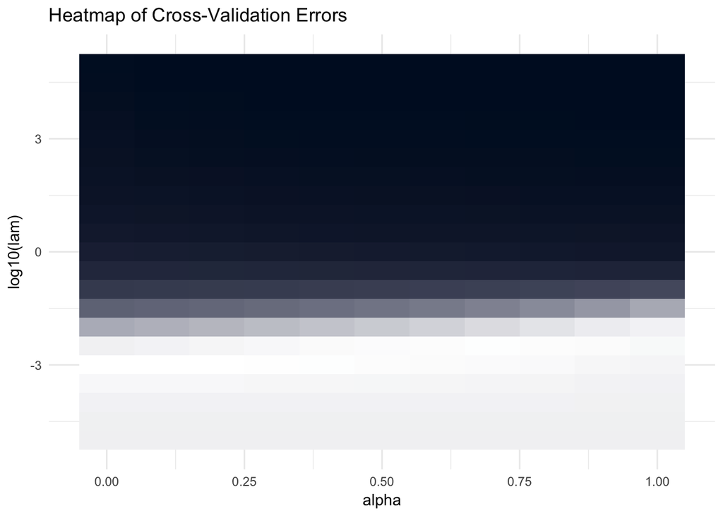

```r
# produce CV heat map for ADMMsigma
ADMMsigma(X) %>% plot
```

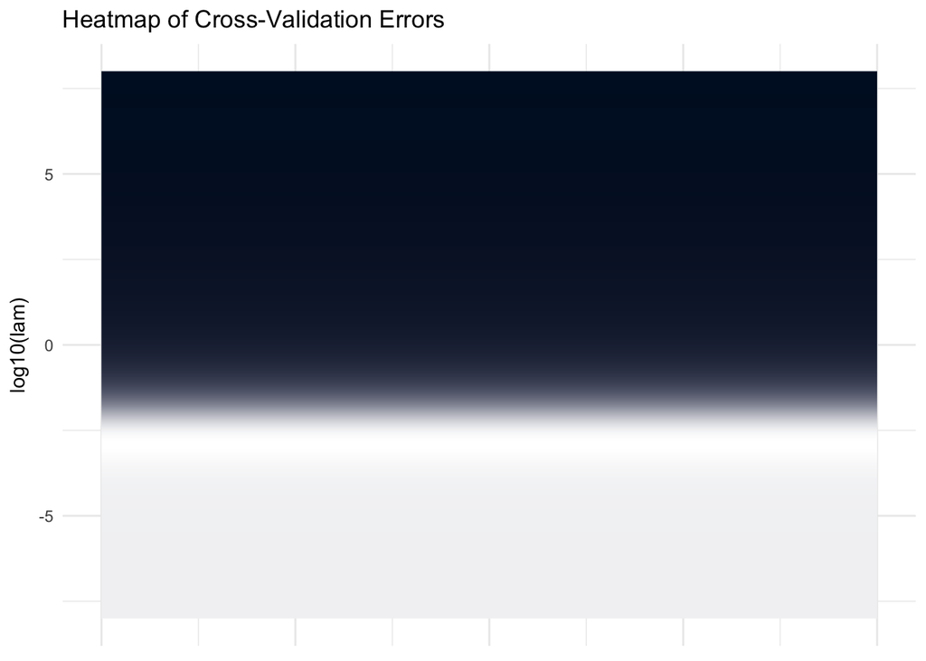

```r
# produce CV heat map for RIDGEsigma
RIDGEsigma(X, lam = 10^seq(-8, 8, 0.01)) %>%
    plot
```

## Benchmark

### Computer Specs:

- MacBook Pro (Late 2016)
- Processor: 2.9 GHz Intel Core i5
- Memory: 8GB 2133 MHz
- Graphics: Intel Iris Graphics 550

```r
# generate data from tri-diagonal
# (sparse) matrix for example first
# compute covariance matrix (can confirm
# inverse is tri-diagonal)
S = matrix(0, nrow = 100, ncol = 100)

for (i in 1:100) {
    for (j in 1:100) {
        S[i, j] = 0.7^(abs(i - j))
    }
}

# generate 1000x100 matrix with rows
# drawn from iid N_p(0, S)
Z = matrix(rnorm(1000 * 100), nrow = 1000,
    ncol = 100)
out = eigen(S, symmetric = TRUE)
S.sqrt = out$vectors %*% diag(out$values^0.5) %*%
    t(out$vectors)
X = Z %*% S.sqrt


# glasso
microbenchmark(glasso(s = S, rho = 0.1),
    times = 5)
```

```
## Unit: milliseconds
##                      expr      min       lq     mean   median       uq
##  glasso(s = S, rho = 0.1) 53.54058 54.35726 57.35062 55.91144 57.97819
##       max neval
##  64.96563     5
```

```r
# benchmark ADMMsigma - default tolerance
microbenchmark(ADMMsigma(S = S, lam = 0.1,
    alpha = 1, tol1 = 1e-04, tol2 = 1e-04))
```

```
## Unit: milliseconds
##                                                                expr
##  ADMMsigma(S = S, lam = 0.1, alpha = 1, tol1 = 1e-04, tol2 = 1e-04)
##       min       lq    mean   median       uq     max neval
##  64.40327 67.16072 74.2923 70.82052 79.19368 106.552   100
```

```r
# benchmark ADMMsigma - tolerance 1e-8
microbenchmark(ADMMsigma(S = S, lam = 0.1,
    alpha = 1, tol1 = 1e-08, tol2 = 1e-08))
```

```
## Unit: milliseconds
##                                                                expr
##  ADMMsigma(S = S, lam = 0.1, alpha = 1, tol1 = 1e-08, tol2 = 1e-08)
##       min       lq     mean   median       uq      max neval
##  291.0441 293.4945 306.1864 297.1832 303.3421 466.4161   100
```

```r
# benchmark ADMMsigma CV - likelihood
# convergence criteria
microbenchmark(ADMMsigma(X, lam = 10^seq(-8,
    8, 0.1), alpha = 1, crit = "loglik"),
    times = 5)
```

```
## Unit: seconds
##                                                                expr
##  ADMMsigma(X, lam = 10^seq(-8, 8, 0.1), alpha = 1, crit = "loglik")
##       min      lq     mean   median       uq     max neval
##  24.33782 24.5952 25.00484 25.00752 25.07295 26.0107     5
```

```r
# benchmark ADMMsigma CV
microbenchmark(ADMMsigma(X, lam = 10^seq(-8,
    8, 0.1), alpha = 1), times = 5)
```

```
## Unit: seconds
##                                               expr      min       lq
##  ADMMsigma(X, lam = 10^seq(-8, 8, 0.1), alpha = 1) 13.64255 13.68542
##      mean   median       uq      max neval
##  13.80014 13.72121 13.74892 14.20262     5
```